# DATA2002 Assignment-1

500594412

University of Sydney | DATA2002 | September 2021

# 1 Introduction

### 1.0.1 General Discussion

The dataset used in the project is retrieved from the survey results conducted in DATA2X02 lecture. They survey was also posted on the official USYD discussion forum (Ed) and on the Canvas Homepage for DATA2x02. This way, it was accessible to every student enrolled in the DATA2X02 units. Furthermore, this also suggests that the sample was a randomly selected sample, as each enrolled student had an equal probability of filling out the survey, and thus having their answers included in the final result dataset.

Another **response bias** was introduced due to the diverse participants of the survey- all students hailed from different geographic locations, and so, several answers may differ due to those factors. For example, every country makes use of different social medias, and also differs in the average salary of a data scientist depending on their economy.

Completely opposite to the response bias would be the **non-response bias**, which occurred due to students missing out on the lecture, and in turn, the survey. Since attendance wasn’t mandatory and survey was active only for a short period of time, out of 754 students, only 218 students took part; of those 218, not everyone answered all questions–the missing potential data created a non-response bias.

Additionally, the survey was structured to be done combined for both units students (DATA2002 & DATA2902) however there were more DATA2002 students then DATA2902 (696 vs 58). Therefore question which ask about the R coding capability or which unit students are enrolled in are saturated to be biased in one direction. This is an example of **measurement bias.**

Lastly a sample of **observer bias** would asking how do they prefer their steak, because it was assumed every participant in the study was Non-Vegetarian.

While the survey answers were completely anonymous, allowing the particpants to be transparent with their answers, few questions were framed in such a way to make make it easy to misinterpret them:

· **Question 22** – ambiguous as to which units are they referring to

Ex: Between DATA2002 and DATA2902, which one are you enrolled in?

· **Question 7 and 8** - Quantitative scale of measurement should have been given. There is no medium to measure the response.

· **Question 4 and 21** - No response validation due to unstructured format of responses.

Ex: (Give responses in cm/metres) / or (just type in the number)

· **Question 11** – Phrasing could have been improved, and a quantitative scale could have been provided for ranking

Ex: How often do you switch on your camera in tutorial per week?

· **Question 14**- Could have been framed better

Ex: which gender do you identify with?

· **Question 19** - Contains ambiguity as “non-spam” emails could hold different interpretations with different people. Should be more specific.

· **Question 13**: Question could have been altered to provide better insights and more connectivity with other questions

Ex: How many hours do you spend on Social Media each week?

# 2 Data Analysis

## 2.1 Data set Import

Importing the data set and storing it in a variable called as ‘survey’.

```r
survey = readr::read_csv("DATA2X02 survey.csv")
```

## 2.2 Package import

Importing all the packages used in the report.

```r
library(dplyr)
library(hrbrthemes)
library(tibble)
library(readr)
library(ggplot2)
library(formattable)
library(knitr)
```

## 2.3 Data Processing

```r
#Setting up dataframe


short_names = c("time","covid_tests","living_arrangements","height",
                "wednesday","location","math_ability","r_ability",
                "data2002","year","webcam","vaccination","social_media",
                "gender","steak_preference","dominant_hand","stress",
                "lonely","emails","sign_off","salary","unit","major","exercise")
colnames(survey) = short_names
survey_new <- select(survey, 1:24)
```

## 2.4 Data Exploration

### 2.4.1 Question 1: Does the number of COVID tests a student has taken in the past two months follow a Poisson distribution?

The Poisson distribution is used to find the probability of an event occurring in a specific time period.It will give a better understanding of the Covid testing trend and willingness of students to get tested within a set period of time.

In order to check if our data fits the model, we will set up a Chi-Squared Goodness of Fit test.

**Null Hypothesis (H0)**: Number of COVID tests taken by students in the past two months follow a Poisson distribution.

**Alternative Hypothesis (H1)**: Number of COVID tests taken by students in the past two months *do not* follow a Poisson distribution.

**Assumptions:**

1. No Expected Frequency is <5 (Cochran’s rule)
2. All observations are independent

**Test Statistic:**

$$\begin{equation}
\ TS = \frac{(OV - EV)^{2}}{EV}
\end{equation}$$

Under H0, T∼χ22 approximately.

**Data Analysis:**

In order to carry out the test, we first extract the Covid test column from our data set and wrangle the data as the following steps:

1. Removing NA values
2. Creating a frequency table outlining number of occurrences of number of Covid tests

```r
covid_tests = c(na.omit(survey_new$covid_tests))
group_table = table(covid_tests)
group_table
```

```
covid_tests
  0   1   2   3   4   5   6   7   8  10
126  40  16   4   5   9   1   1   4   2
```

Next, we calculate our total sample size and call it “n”. We estimate our lambda parameter for the poisson distribution by taking the mean of covid_tests and omitting any NA values.

```r
tests_vector = c(126, 40, 16, 4, 5, 9, 1, 1, 4, 0, 2)
```

Then we calculate the total size of our data (excluding the NA values) and store it in a variable called as “total_tests”:

```r
total_tests = length(covid_tests)
k = length(group_table)
```

**Checking Assumptions**

1. Independency

   Each value had an equal likelihood of occurrence in the dataset. **(Satisfied)**
2. No Expected Frequency is <5

   The expected values are calculated using the hypothesized probability; specifically, by multiplying the total sample size with the dpois() and ppois() functions :

```r
lam = mean(covid_tests, na.rm = TRUE)
hp = c(dpois(0:9, lam), ppois(9, lam, lower.tail = FALSE))
ev = total_tests * hp
```

```
Expected Values:
```

```
74.34318 76.48769 39.34703 13.49402 3.470816 0.7141872 0.1224648 0.01799963 0.002314857 0.0002646257 3.000936e-05
```

However, since few of the expected values are less than 5, we group categories which do not satisfy our assumptions in expected as well as observed values:

```r
new_ev = c(ev[1:3], sum(ev[4:11]))
new_ov = c(tests_vector[1:3], sum(tests_vector[4:11]))

#probability of expected counts -> to be used with chi.sq
pr = c(hp[1:3], sum(hp[4:11]))
```

We can view the distribution of the covid testing trend from the plot below. It highlights the highest number of covid testing in the past 2 months:

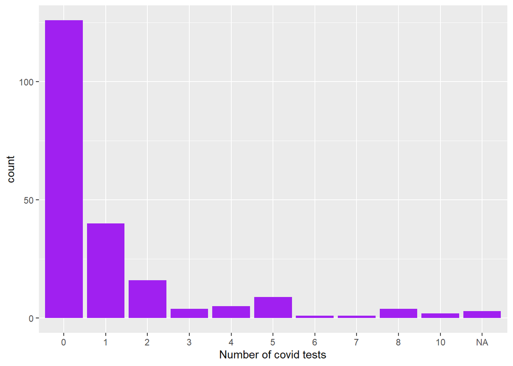

```r
ggplot(survey_new,aes(as.factor(covid_tests)))+ geom_histogram(na.rm = TRUE,stat="count", fill="purple") + xlab("Number of covid tests")+ylab("count")
```

Finally we calculate the lambda parameter for the poisson distribution by finding the mean of the covid tests. Additionally, To calculate our test statistic, we use the formula defined above and using that, we calculate the p-value of our chi.sq test:

```r
test_stat = sum((new_ov - new_ev )^2/new_ev)

kr  = length(new_ev)
p_value = (1 - pchisq(test_stat, df = kr -1-1))
# df = 2 as 4 -1 - 1 as 4 categories and 1 lamda parameter

a<-chisq.test(new_ev, p = pr)
```

```
P-Value:  4.440892e-16
```

```
Test Statistic:  70.90525
```

As we can see, the p-value is much less than 0.05 (critical value), therefore, we **reject the null hypothesis**. Covid testing trend doesn’t seem consistent with the poisson distribution.

### 2.4.2 Question 2: Is the distribution of male students equal to the distribution of female students in Data 2x02 units?

‘Women in STEM’ is a global idea encouraging more females to pursue STEM related careers. However, the gender gap between this field is still quite contrasting. Thus, I am checking to see whether the distribution of male and female population in the field of data science are same or not.

In order to check if both of our data, male and female, follow the same distribution of enrollment in data2x02 units, we will set up a **Chi-Squared test of homogeneity**.

**Null Hypothesis (H0)**: The distribution of male students in Data2x02 units is the same as the distribution of female students in Data2x02 units.

**Alternative Hypothesis (H1)**: The distribution of male students in Data2x02 units is not the same as the distribution of female students in Data2x02 units.

**Critical Value**: 0.05

**Assumptions:**

1. No Expected Frequency is <5 (Cochran’s rule)
2. observations randomly sampled from two independent populations

**Test Statistic:**

$$\begin{equation}
\ TS = \frac{(OV - EV)^{2}}{EV}
\end{equation}$$

First, we extract the gender and the data2x02 unit columns, and carry out the following steps to filter:

1. Remove the empty NA rows
2. Remove the gender ‘Non-Binary’ rows.
3. Format all different entries of Female and Male to uniform entries: “F”/“M”
4. Create a 2x2 contingency table to simplify our analysis:

```r
survey_new <- survey_new[!is.na(survey_new$gender),]
survey_new <- survey_new[!is.na(survey_new$unit),]
survey_new<-survey_new %>% filter(gender != 'Non-binary')
db = subset(survey_new, select = c(gender,unit))

db$gender[db$gender == "Female" | db$gender== "female" | db$gender == "Woman"| db$gender == "Woman/Female" | db$gender == "Femal" | db$gender == "Famale"|db$gender == "f"  ] <- "F"

db$gender[db$gender == "male" | db$gender== "Male" | db$gender == "man"| db$gender == "Man" | db$gender == "m"|db$gender == "MALE" ] <- "M"
```

```r
dat = db %>%
  mutate(unit = factor(unit, levels = c("DATA2002", "DATA2902 (Advanced)")),
         gender = factor(gender, levels = c("F","M")))


tab <- table(dat$gender, dat$unit)

tab <- cbind(tab, `Row total` = rowSums(tab))
tab <- rbind(tab, `Column total` = colSums(tab))
```

**Checking assumptions:**

1. Independence

   Enrollment of a female does not affect the enrollment of a male in any DATA2X02 unit; they are unrelated and each have an equal likelihood of enrollment. **(Satisfied)**
2. All EV are greater than or equal to 5

```r
 trial <- matrix(c(((169*76)/205),((169*129)/205),((36*76)/205),((36*129)/205)), ncol=2)
 colnames(trial) <- c('DATA2002', 'DATA2902(Advanced)')
 rownames(trial) <- c('EV males', 'EV females')
 trial.table <- as.table(trial)
trial.table >= 5
```

```
           DATA2002 DATA2902(Advanced)
EV males       TRUE               TRUE
EV females     TRUE               TRUE
```

**(Satisfied)**

*Expected counts* under the null hypothesis is calculated by the following formula:

$$\begin{equation}
\\ EV = \frac{Row_{total} \times{Column_{total}}}{overall_{total}}
\end{equation}$$

```r
trial.table
```

```
            DATA2002 DATA2902(Advanced)
EV males    62.65366           13.34634
EV females 106.34634           22.65366
```

Next, using the expected and the observed values table, we calculate the observed test statistic by the following formula and then sum up the values:

$$\begin{equation}
TS = \frac{(OV - EV)^{2}}{EV}\
\end{equation}$$

```r
tab1 <- table(dat$gender, dat$unit)
ov <- matrix(data = tab1, nrow = 2, ncol = 2)
ev <- matrix(data = trial.table, nrow = 2, ncol = 2)
ts <- sum((ov-ev)^2/ev)
```

```
Observed Test Statistic:  5.817226
```

```r
chisq.test(tab1, correct = FALSE)
```

```
    Pearson's Chi-squared test

data:  tab1
X-squared = 5.8172, df = 1, p-value = 0.01587
```

**Results:**

**Rejecting H0** as the p-value is quite small, i.e. there is evidence to suggest that the data sample are heterogeneous; the distribution of male students in Data2x02 units is not the same as the distribution of female students in Data2x02 units.

We can observe the distribution by plotting a bar graph of the proportion of gender distribution in each data unit, which clearly show that the distribution of males in both the units are much higher than females:

```r
tab1 <- table(dat$gender, dat$unit)
data <- matrix(data = tab1, nrow = 2, ncol = 2)
data
```

```
     [,1] [,2]
[1,]   69    7
[2,]  100   29
```

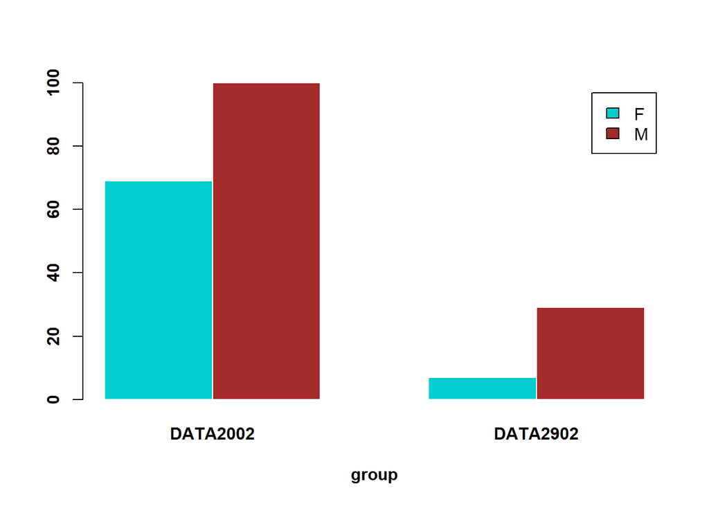

```r
colnames(data) <- c("DATA2002","DATA2902")
rownames(data) <- c("F","M")

# Grouped barplot
barplot(data,
        col=colors()[c(71,32)] ,
        border="white",
        font.axis=2,
        beside=T,
        legend=rownames(data),
        xlab="group",
        font.lab=2)
```

### 2.4.3 Question 3: Are the average heights of male same as average height of females?

It is a general stereotype that males are taller than females. While it does have a biological explanation, height is actually determined by **both genetic and environmental influences** (Kingsley, 2021). Therefore, it’d be interesting to see whether this global trend still hold in a diverse classroom of students from all across the world.

In order to check if the average heights of our male and female sample populations are same, we will set up a **two sample T-Test**. This is because we want to compare the means of two independent groups.

**Null Hypothesis (H0)**: Average heights of female and male students are the same; True difference between the mean heights of male and female is $=$ 0.

**Alternative Hypothesis (H1)**: Average heights of female and male students are not the same; True difference between the mean heights of male and female is $\neq$ 0.

**Assumptions:**

1. Each height value in the sample had an equal likelihood of occurring in the data set and were independent of each other

2. Observations for height follows a normal model

3. Two underlying normal populations *have the same variance*.

**Data Analysis:**

First, we will extract the gender and the height column from our data set. In order to do that, we will clean the data. Data cleaning was done using the code from Tarr(2021):

1. Convert height data to uniform values
2. Make Gender data uniform
3. Remove NA values

Final data set stored in ‘db’.

```r
survey_new %>% filter(gender != 'Non-binary')
```

```
# A tibble: 205 x 24
   time      covid_tests living_arrangem~ height wednesday location math_ability
   <chr>           <dbl> <chr>            <chr>  <chr>     <chr>           <dbl>
 1 20/08/20~           0 With parents     178cm  Monday    No                  6
 2 20/08/20~           2 With parents     1.88m  Monday    Yes                 5
 3 20/08/20~           0 With parents     185cm  Monday    Yes                 9
 4 20/08/20~           0 With parents     165 cm Monday    Yes                 7
 5 20/08/20~           0 With parents     180    Friday    Yes                 6
 6 20/08/20~           1 With partner     172cm  Monday    Yes                 8
 7 20/08/20~           0 With parents     179cm  Friday    Yes                10
 8 20/08/20~           0 With one parent  1.90cm Monday    Yes                 7
 9 20/08/20~           0 With parents     154 cm Friday    Yes                 9
10 20/08/20~           0 With parents     185cm  Monday    Yes                 6
# ... with 195 more rows, and 17 more variables: r_ability <dbl>,
#   data2002 <chr>, year <chr>, webcam <chr>, vaccination <chr>,
#   social_media <chr>, gender <chr>, steak_preference <chr>,
#   dominant_hand <chr>, stress <dbl>, lonely <dbl>, emails <dbl>,
#   sign_off <chr>, salary <chr>, unit <chr>, major <chr>, exercise <dbl>
```

```r
survey_new = survey_new %>%
  dplyr::mutate(
    height_clean = readr::parse_number(height),
    height_clean = case_when(
      height_clean <= 2.5 ~ height_clean * 100, #m to cm
      height_clean <= 9 ~ NA_real_, #feet to NA of type real
      TRUE ~ height_clean
    )
  )

survey_new <- survey_new[!is.na(survey_new$gender),]
survey_new <- survey_new[!is.na(survey_new$height_clean),]

db = subset(survey_new, select = c(gender,height_clean))

db$gender[db$gender == "Female" | db$gender== "female" | db$gender == "Woman"| db$gender == "Woman/Female" | db$gender == "Femal" | db$gender == "Famale"|db$gender == "f"  ] <- "F"

db$gender[db$gender == "male" | db$gender== "Male" | db$gender == "man"| db$gender == "Man" | db$gender == "m"|db$gender == "MALE" ] <- "M"


male_h = c(db$height_clean[db$gender == "M"])
female_h = c(db$height_clean[db$gender == "F"])
```

**Checking Assumptions:**

1. *Independency*

   All heights had an equal occurrence of being included in the data set. **(Satisfied)**
2. *Normal distribution*

   To test for normality, we will plot a QQ plot:

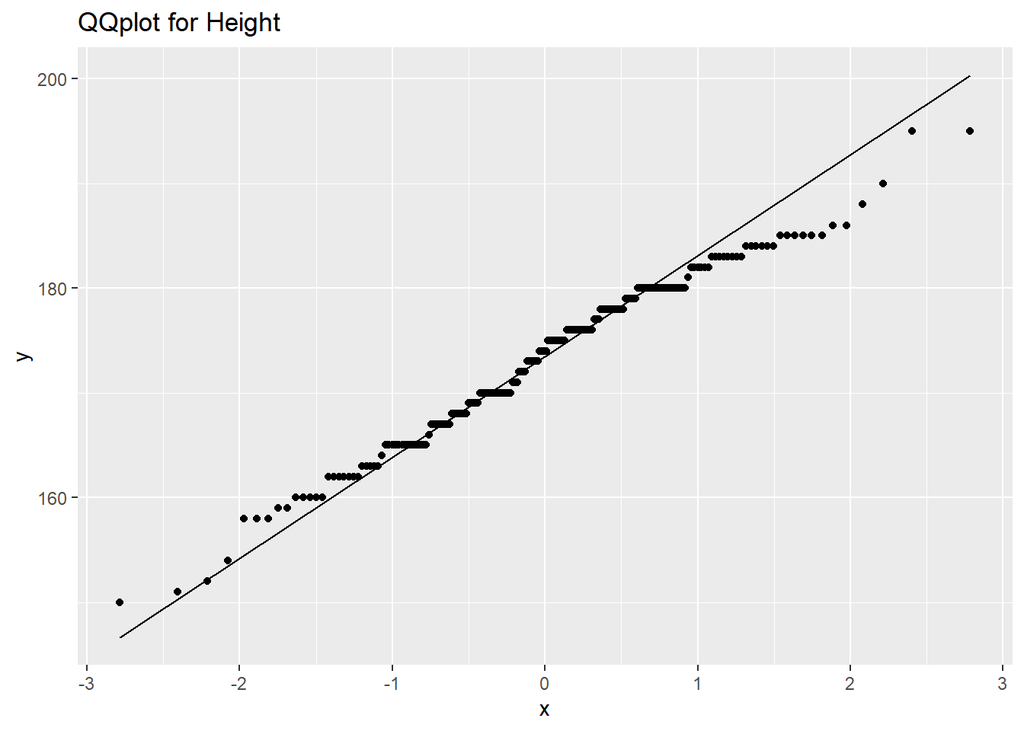

```r
H <- db$height_clean


ggplot(db, aes(sample = H)) +
     stat_qq(aes(color = H)) + stat_qq_line() + ggtitle("QQplot for Height") + scale_color_manual(values = c("#00AFBB", "#E7B800"))
```

A quantile-quantile (Q-Q) plot shows:

* Observations lies approximately on a straight line; uneven scattering towards of the line could be due to possible outliers.

* Strong support for normality **(Satisfied)**

3. *Similar variances*

[output not shown]

[output not shown]

**(Satisfied)**

Using our wrangled data, we will perform some elementary operations to find the mean and the standard deviation, and use a box plot to visually see our data:

```r
dat = data.frame(
  platelets = c(male_h, female_h),
  Heights = c(rep("Male",
                 length(male_h)),
             rep("Female",
                 length(female_h)))
)
library(dplyr)
sum = dat %>%
  group_by(Heights) %>%
  summarise(Mean = mean(platelets),
            SD = sd(platelets),
            n = n())
knitr::kable(sum, format = "html", digits = 1)
```

| Heights | Mean | SD | n |
| --- | --- | --- | --- |
| Female | 165.2 | 5.8 | 69 |
| Male | 177.9 | 5.8 | 117 |

```r
sum
```

```
# A tibble: 2 x 4
  Heights  Mean    SD     n
  <chr>   <dbl> <dbl> <int>
1 Female   165.  5.78    69
2 Male     178.  5.76   117
```

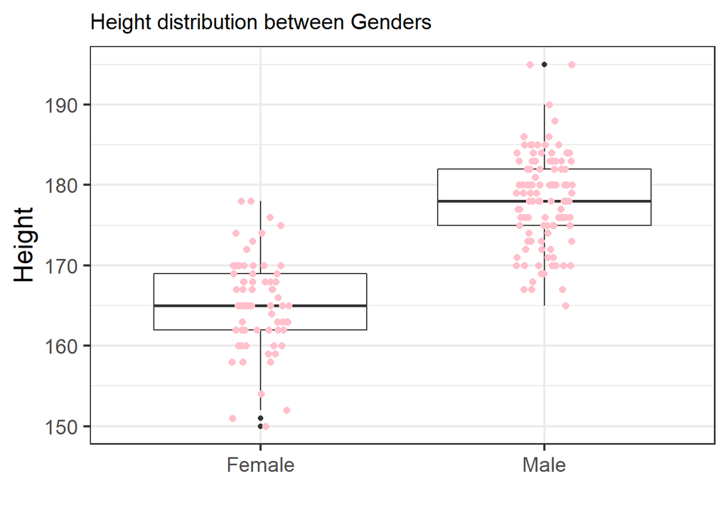

```r
library("ggplot2")
ggplot(dat, aes(x = Heights, y = platelets)) +
  geom_boxplot() +
  geom_jitter(width=0.10, size = 2, colour = "pink") +
  theme_bw(base_size = 28) +
  labs(x = "", y = "Height")+

  scale_fill_brewer(palette="BuPu") +   theme_bw(base_size = 18) +


  ggtitle("Height distribution between Genders")+

    theme(

      plot.title = element_text(size=15))
```

We will conduct our T-test:

```r
t.test(female_h, male_h, alternative = "two.sided", var.equal = TRUE)
```

```
    Two Sample t-test

data:  female_h and male_h
t = -14.481, df = 184, p-value < 2.2e-16
alternative hypothesis: true difference in means is not equal to 0
95 percent confidence interval:
 -14.40172 -10.94796
sample estimates:
mean of x mean of y
 165.1884  177.8632
```

```r
nS = length(female_h)
nN = length(male_h)
sS = sd(female_h)
sN = sd(male_h)
sP = sqrt(((nS - 1) * sS^2 + (nN - 1) * sN^2)/
            (nS + nN - 2))
xbarS = mean(female_h)
xbarN = mean(male_h)
deg_free = nS+nN-2
t0 = (xbarS - xbarN)/(sP * sqrt(1/nS + 1/nN))
p_val = 2 * (1 - pt(abs(t0), deg_free))
```

```
Test Statistic:  -14.48088
```

```
P-value:  0
```

**Result**:

We reject the null hypothesis as p-value is too small; we have evidence against the true difference between the means of both sample being 0. Therefore, the data suggests that female and male students have different average heights; male students seem to be taller on average than females.

Result makes sense since males in general are said to be taller by 13cm; Testosterone triggers cells all over the body to grow as found by (BBC - Science & Nature - Human Body and Mind - Teenagers, 2021).

### 2.4.4 Question 4: Are scores in R coding capability independent of scores in Mathematics ability

It is natural to assume that an individual who is good at math, would also be good at R coding. Since R is often considered to go hand-in-hand with statistics, it seems only logical to create a relationship between the two. Therefore, we are checking whether they are actually related or are independent of each other.

For this, we set up a **Chi Squared test of independence:**

**Null Hypothesis (H0)**: Capability in R coding is independent of scores in Mathematics

**Alternative Hypothesis (H1)**: Capability in R coding is not independent of scores in Mathematics

**Critical Value**: 0.05

**Assumptions:**

1. independent observations
2. Observation values should be greater than or equal to 5

**Data Analysis:**

1. Removing the NA values
2. Categorizing the quantitative variables into qualitative variables
3. Creating a 3x3 contingency table with a totals row and column (4x4)

```r
survey_new <- survey_new[!is.na(survey_new$math_ability),]
survey_new <- survey_new[!is.na(survey_new$r_ability),]
db = subset(survey_new, select = c(math_ability,r_ability))

df = db %>%
  dplyr::mutate(
    r_skills = r_ability,
    r_skills  = case_when(
      r_skills  <= 4 ~ "incompetent",
      r_skills  <= 7 ~ "average",
      r_skills  <= 10 ~ "proficient"
    )
  )
df = df %>%
  dplyr::mutate(
    m_skills  = math_ability,
    m_skills  = case_when(
      m_skills <= 4 ~ "incompetent",
      m_skills <= 7 ~ "average",
      m_skills <= 10 ~ "proficient"
    )
  )

dat = df %>%
  mutate(r_skills = factor(r_skills, levels = c("incompetent", "average", "proficient")),
         m_skills = factor(m_skills, levels = c("incompetent", "average", "proficient")))


tab <- table(dat$r_skills, dat$m_skills)
colnames(tab) <- c("M_incompetent", "M_average", "M_proficient")
rownames(tab) <- c("R_incompetent", "R_average", "R_proficient")




#4x4 contingency table
tab <- cbind(tab, `Row total` = rowSums(tab))
tab <- rbind(tab, `Column total` = colSums(tab))

tab
```

```
              M_incompetent M_average M_proficient Row total
R_incompetent            15        34           17        66
R_average                 7        60           44       111
R_proficient              0         4            5         9
Column total             22        98           66       186
```

**Checking Assumptions:**

1. *Independence:*

   Since the sample was randomly selected, all observations had an equal likelihood of occurring **(Satisfied).**
2. *Observations >=5:*

   ```r
   y.mat = matrix(tab, nrow = 3, ncol = 3)
   y.mat
   ```

   ```
        [,1] [,2] [,3]
   [1,]   15   22    4
   [2,]    7   34   98
   [3,]    0   60   17
   ```

Before carrying out the test, we first visually represent the data:

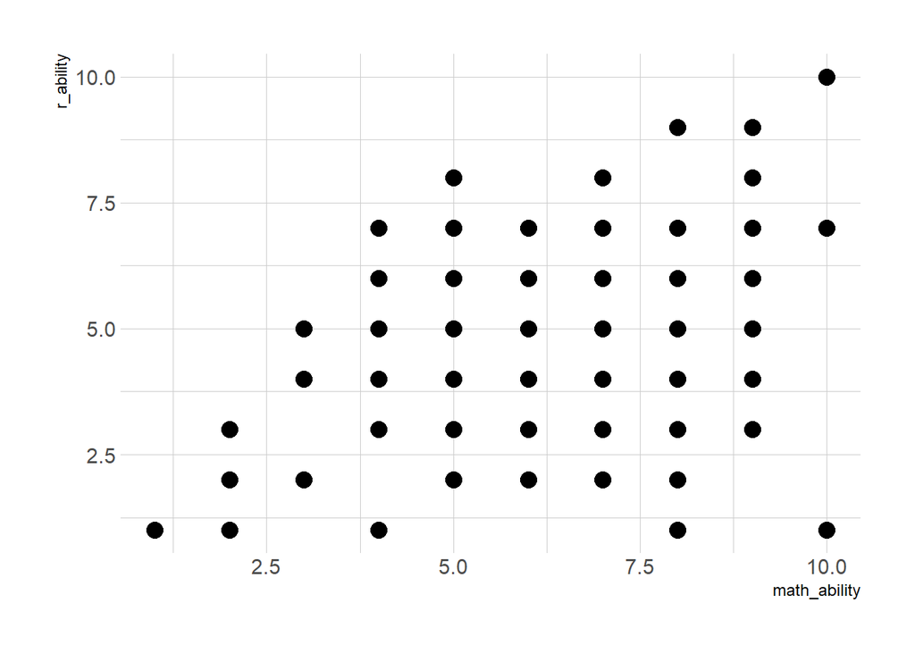

```r
ggplot(db, aes(x=math_ability, y=r_ability)) +
    geom_point(size=4)+theme_ipsum()
```

From the graph, we see a positively correlated data, such that, if one increases, other variable seems to increase.

```r
chisq.test(y.mat, simulate.p.value = TRUE, B = 10000)
```

```
    Pearson's Chi-squared test with simulated p-value (based on 10000
    replicates)

data:  y.mat
X-squared = 117.55, df = NA, p-value = 9.999e-05
```

**Result**:

This shows support for our alternative hypothesis as individuals who tend to perform better in math, develop skills of logic and analytics proves beneficial while coding in R.

# 3 Conclusion

# 4 Acknowledgements

- Ed posts:
  - [Help](https://edstem.org/au/courses/6600/discussion/599969) with converting factor to numeric levels
  - [Help](https://edstem.org/au/courses/6600/discussion/582393) with tibble value type (char vs numeric)
- Stack Overflow:
  - [Help](https://stackoverflow.com/questions/16147915/how-to-convert-continuous-variable-to-discrete-in-r) with continuous to discrete conversion
  - [Help](https://stackoverflow.com/questions/15589601/print-string-and-variable-contents-on-the-same-line-in-r) with printing strings
  - [Help](https://stackoverflow.com/questions/56777251/how-to-conditionally-color-table-elements-using-formattable-and-color-tile) with conditionally formatting formattable table
  - [Help](https://stackoverflow.com/questions/49084904/r-markdown-bullet-list-with-multiple-levels) with different bullet-list levelling
  - [Help](https://stackoverflow.com/questions/5831794/opposite-of-in-exclude-rows-with-values-specified-in-a-vector) with filtering and excluding rows

# 5 References

1. Kingsley, D., 2021. *Genes explain why men are taller › News in Science (ABC Science)*. [online] Abc.net.au. Available at: https://www.abc.net.au/science/articles/2001/09/11/363100.htm [Accessed 21 September 2021].
2. Tarr, G (2021). DATA2002 Data Analytics: Learning from Data. University of Sydney, Sydney Australia.
3. Bbc.co.uk. 2021. *BBC - Science & Nature - Human Body and Mind - Teenagers*. [online] Available at: https://www.bbc.co.uk/science/humanbody/body/articles/lifecycle/teenagers/boy_s_growth.shtml [Accessed 21 September 2021].